# Introduction

To read the report click here

```python
#importing packages to analyze the data
import pandas as pd
import numpy as np
import matplotlib.pyplot as plt
import seaborn as sns
plt.style.use('seaborn')
sns.set(rc={'figure.figsize':(11.7,8.27)})
pd.options.display.max_rows = 999

#reading in the data set
lifeexp = pd.read_csv('Life Expectancy Data.csv', header=0)
```

```python
# Looking at data before any sort of preprocessing
lifeexp.shape
lifeexp.head(10)
lifeexp.tail(10)
```

|  | Country | Year | Status | Life expectancy | Adult Mortality | infant deaths | Alcohol | percentage expenditure | Hepatitis B | Measles | ... | Polio | Total expenditure | Diphtheria | HIV/AIDS | GDP | Population | thinness 1-19 years | thinness 5-9 years | Income composition of resources | Schooling |
| --- | --- | --- | --- | --- | --- | --- | --- | --- | --- | --- | --- | --- | --- | --- | --- | --- | --- | --- | --- | --- | --- |
| 2928 | Zimbabwe | 2009 | Developing | 50.0 | 587.0 | 30 | 4.64 | 1.040021 | 73.0 | 853 | ... | 69.0 | 6.26 | 73.0 | 18.1 | 65.824121 | 1381599.0 | 7.5 | 7.4 | 0.419 | 9.9 |
| 2929 | Zimbabwe | 2008 | Developing | 48.2 | 632.0 | 30 | 3.56 | 20.843429 | 75.0 | 0 | ... | 75.0 | 4.96 | 75.0 | 20.5 | 325.678573 | 13558469.0 | 7.8 | 7.8 | 0.421 | 9.7 |
| 2930 | Zimbabwe | 2007 | Developing | 46.6 | 67.0 | 29 | 3.88 | 29.814566 | 72.0 | 242 | ... | 73.0 | 4.47 | 73.0 | 23.7 | 396.998217 | 1332999.0 | 8.2 | 8.2 | 0.414 | 9.6 |
| 2931 | Zimbabwe | 2006 | Developing | 45.4 | 7.0 | 28 | 4.57 | 34.262169 | 68.0 | 212 | ... | 71.0 | 5.12 | 7.0 | 26.8 | 414.796232 | 13124267.0 | 8.6 | 8.6 | 0.408 | 9.5 |
| 2932 | Zimbabwe | 2005 | Developing | 44.6 | 717.0 | 28 | 4.14 | 8.717409 | 65.0 | 420 | ... | 69.0 | 6.44 | 68.0 | 30.3 | 444.765750 | 129432.0 | 9.0 | 9.0 | 0.406 | 9.3 |
| 2933 | Zimbabwe | 2004 | Developing | 44.3 | 723.0 | 27 | 4.36 | 0.000000 | 68.0 | 31 | ... | 67.0 | 7.13 | 65.0 | 33.6 | 454.366654 | 12777511.0 | 9.4 | 9.4 | 0.407 | 9.2 |
| 2934 | Zimbabwe | 2003 | Developing | 44.5 | 715.0 | 26 | 4.06 | 0.000000 | 7.0 | 998 | ... | 7.0 | 6.52 | 68.0 | 36.7 | 453.351155 | 12633897.0 | 9.8 | 9.9 | 0.418 | 9.5 |
| 2935 | Zimbabwe | 2002 | Developing | 44.8 | 73.0 | 25 | 4.43 | 0.000000 | 73.0 | 304 | ... | 73.0 | 6.53 | 71.0 | 39.8 | 57.348340 | 125525.0 | 1.2 | 1.3 | 0.427 | 10.0 |
| 2936 | Zimbabwe | 2001 | Developing | 45.3 | 686.0 | 25 | 1.72 | 0.000000 | 76.0 | 529 | ... | 76.0 | 6.16 | 75.0 | 42.1 | 548.587312 | 12366165.0 | 1.6 | 1.7 | 0.427 | 9.8 |
| 2937 | Zimbabwe | 2000 | Developing | 46.0 | 665.0 | 24 | 1.68 | 0.000000 | 79.0 | 1483 | ... | 78.0 | 7.10 | 78.0 | 43.5 | 547.358878 | 12222251.0 | 11.0 | 11.2 | 0.434 | 9.8 |

10 rows × 22 columns

# Checking variable description and rewriting if wrong.

- The histograms in kaggle do not provide an accurate picture of the information.
- Adult mortality: number of deaths in a population of 1000 that are between the ages of 15-60.
- Under five deaths: deaths occuring under age 5 in a population of 1000
- Alcohol is consumed per capita (15+ years) over a calendar year in a country, in litres of pure alcohol
- Infant mortality rate (dying between birth and age 1 per 1000 live births)

```python
# Finding out what types of variables the data set is comprised off.
lifeexp.describe()#summary statistics of numeric columns
lifeexp.info(verbose=True)
```

```
<class 'pandas.core.frame.DataFrame'>
RangeIndex: 2938 entries, 0 to 2937
Data columns (total 22 columns):
 #   Column                           Non-Null Count  Dtype
---  ------                           --------------  -----
 0   Country                          2938 non-null   object
 1   Year                             2938 non-null   int64
 2   Status                           2938 non-null   object
 3   Life expectancy                  2928 non-null   float64
 4   Adult Mortality                  2928 non-null   float64
 5   infant deaths                    2938 non-null   int64
 6   Alcohol                          2744 non-null   float64
 7   percentage expenditure           2938 non-null   float64
 8   Hepatitis B                      2385 non-null   float64
 9   Measles                          2938 non-null   int64
 10   BMI                             2904 non-null   float64
 11  under-five deaths                2938 non-null   int64
 12  Polio                            2919 non-null   float64
 13  Total expenditure                2712 non-null   float64
 14  Diphtheria                       2919 non-null   float64
 15   HIV/AIDS                        2938 non-null   float64
 16  GDP                              2490 non-null   float64
 17  Population                       2286 non-null   float64
 18   thinness  1-19 years            2904 non-null   float64
 19   thinness 5-9 years              2904 non-null   float64
 20  Income composition of resources  2771 non-null   float64
 21  Schooling                        2775 non-null   float64
dtypes: float64(16), int64(4), object(2)
memory usage: 505.1+ KB
```

```python
#Getting a sample of the data
lifeexp.sample(10)
```

|  | Country | Year | Status | Life expectancy | Adult Mortality | infant deaths | Alcohol | percentage expenditure | Hepatitis B | Measles | ... | Polio | Total expenditure | Diphtheria | HIV/AIDS | GDP | Population | thinness 1-19 years | thinness 5-9 years | Income composition of resources | Schooling |
| --- | --- | --- | --- | --- | --- | --- | --- | --- | --- | --- | --- | --- | --- | --- | --- | --- | --- | --- | --- | --- | --- |
| 1802 | Namibia | 2009 | Developing | 62.4 | 36.0 | 3 | 7.99 | 575.674807 | NaN | 4076 | ... | 83.0 | 8.50 | 83.0 | 8.7 | 4153.497885 | 21374.0 | 1.9 | 1.9 | 0.598 | 11.4 |
| 2816 | Uruguay | 2009 | Developing | 76.6 | 118.0 | 0 | 6.67 | 1871.736563 | 95.0 | 0 | ... | 95.0 | 8.78 | 95.0 | 0.1 | 9415.173860 | 3362755.0 | 1.5 | 1.5 | 0.774 | 15.5 |
| 679 | Cyprus | 2009 | Developed | 79.3 | 6.0 | 0 | 10.80 | 230.252418 | 96.0 | 0 | ... | 99.0 | 7.40 | 99.0 | 0.1 | 3215.815900 | 19876.0 | 0.9 | 1.0 | 0.849 | 14.1 |
| 1706 | Micronesia (Federated States of) | 2008 | Developing | 68.4 | 174.0 | 0 | 1.97 | 0.000000 | 89.0 | 0 | ... | 88.0 | 12.94 | 85.0 | 0.1 | NaN | NaN | 0.2 | 0.2 | 0.628 | 11.2 |
| 1138 | Honduras | 2015 | Developing | 74.6 | 147.0 | 3 | NaN | 0.000000 | 97.0 | 0 | ... | 97.0 | NaN | 97.0 | 0.3 | 2326.158560 | 896829.0 | 2.1 | 2.1 | 0.623 | 11.2 |
| 2293 | Seychelles | 2003 | Developing | 72.1 | 185.0 | 0 | 7.41 | 843.118666 | 99.0 | 0 | ... | 99.0 | 4.64 | 99.0 | 0.1 | 8524.961236 | 82781.0 | 6.1 | 6.5 | 0.713 | 12.1 |
| 447 | Côte d'Ivoire | 2000 | Developing | 47.9 | 461.0 | 67 | 3.45 | 0.000000 | NaN | 5729 | ... | 66.0 | 6.00 | 65.0 | 7.1 | NaN | NaN | 8.1 | 8.1 | NaN | NaN |
| 2479 | Suriname | 2009 | Developing | 70.0 | 196.0 | 0 | 5.13 | 885.073977 | 87.0 | 0 | ... | 85.0 | 6.14 | 87.0 | 0.6 | 7443.851780 | 52619.0 | 3.5 | 3.4 | 0.696 | 12.1 |
| 678 | Cyprus | 2010 | Developed | 79.5 | 59.0 | 0 | 11.32 | 283.330026 | 96.0 | 18 | ... | 99.0 | 7.23 | 99.0 | 0.1 | 3818.463960 | 111267.0 | 0.9 | 1.0 | 0.853 | 14.6 |
| 2935 | Zimbabwe | 2002 | Developing | 44.8 | 73.0 | 25 | 4.43 | 0.000000 | 73.0 | 304 | ... | 73.0 | 6.53 | 71.0 | 39.8 | 57.348340 | 125525.0 | 1.2 | 1.3 | 0.427 | 10.0 |

10 rows × 22 columns

```python
#What are the unique variables in this data set
n = lifeexp.nunique(axis=0)

print("No.of.unique values in each column :\n", n)
```

```
No.of.unique values in each column :
 Country                             193
Year                                 16
Status                                2
Life expectancy                     362
Adult Mortality                     425
infant deaths                       209
Alcohol                            1076
percentage expenditure             2328
Hepatitis B                          87
Measles                             958
 BMI                                608
under-five deaths                   252
Polio                                73
Total expenditure                   818
Diphtheria                           81
 HIV/AIDS                           200
GDP                                2490
Population                         2278
 thinness  1-19 years               200
 thinness 5-9 years                 207
Income composition of resources     625
Schooling                           173
dtype: int64
```

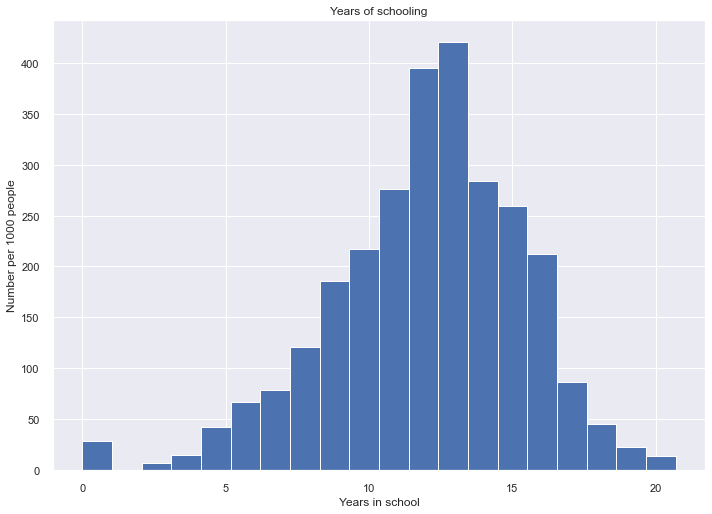

```python
#Histogram if schooling
lifeexp.hist(column='Schooling', bins=20)
plt.title('Years of schooling')
plt.xlabel('Years in school')
plt.ylabel('Number per 1000 people')
```

# Scatter plots

Scatter plots for several countries to analyze the trends for these variables: adult mortality, population, infant death, and schooling

- Developing countries: Afghanistan, Mexico, Romania
- Developed countries: USA, France, Belgium

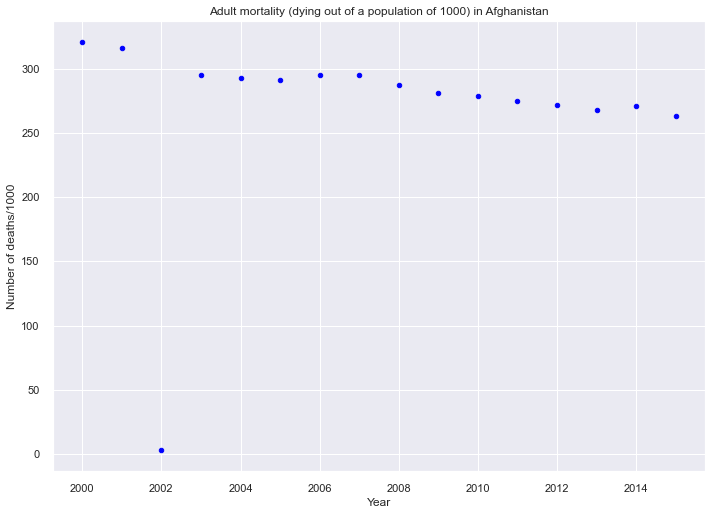

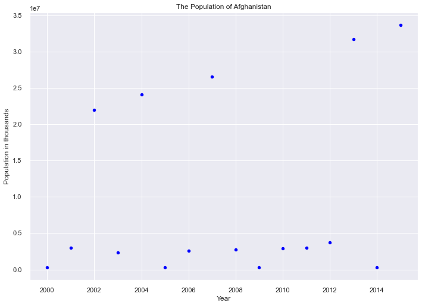

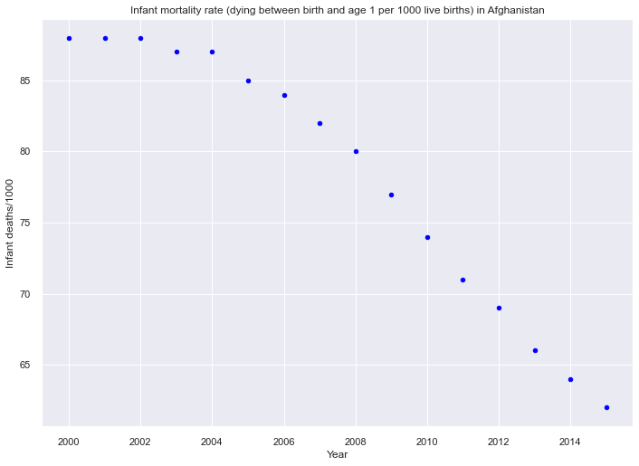

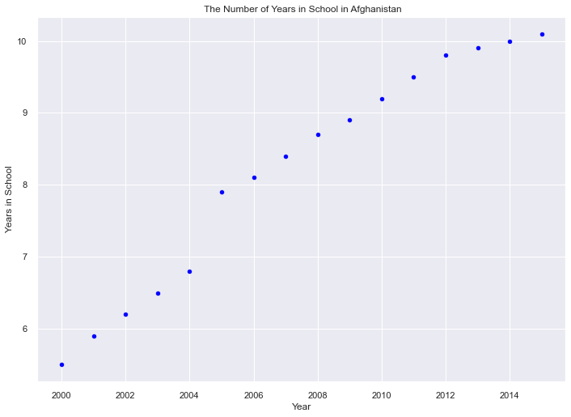

```python
#Afghanistan

afghan_ad = lifeexp[lifeexp['Country']=='Afghanistan']
afghan_ad.plot.scatter('Year','Adult Mortality',c='blue')

plt.ylabel('Number of deaths/1000')
plt.title('Adult mortality (dying out of a population of 1000) in Afghanistan')

afghan_pop = lifeexp[lifeexp['Country']=='Afghanistan']
afghan_pop.plot.scatter('Year','Population',c='blue')
plt.ylabel('Population in thousands')
plt.title('The Population of Afghanistan')

afghan_ifdeath = lifeexp[lifeexp['Country']=='Afghanistan']
afghan_ifdeath.plot.scatter('Year','infant deaths',c='blue')
plt.ylabel('Infant deaths/1000')
plt.title('Infant mortality rate (dying between birth and age 1 per 1000 live births) in Afghanistan')

afghan_school = lifeexp[lifeexp['Country']=='Afghanistan']
afghan_school.plot.scatter('Year','Schooling',c='blue')
plt.ylabel('Years in School')
plt.title(' The Number of Years in School in Afghanistan')
```